# COM747 Week 2: Statistical Computing with R

Lecturer demonstration notebook

# Today’s question

> **Scenario.** I’m the course director. The exam board asks three questions about one class:
> 1. How did the class perform overall? → **descriptive statistics**
> 2. Which students are at risk (below 40)? → **filtering**
> 3. How many achieved a distinction (70+)? → **filtering**

> Then we scale up: generating data, storing it in the right structure, and reading a real CSV file.

**Week 8 practical test:** everything in this notebook is examinable.

# Part 1: Vectors and descriptive statistics

**PREDICT** What does `<-` do? What does `c()` do? How many values will `length()` return?

```r
marks <- c(20, 40, 60, 30, 34, 55, 70, 90, 84, 10, 90)
marks
```

```
##  [1] 20 40 60 30 34 55 70 90 84 10 90
```

```r
length(marks)
```

```
## [1] 11
```

```r
class(marks)
```

```
## [1] "numeric"
```

```r
typeof(marks)
```

```
## [1] "double"
```

```r
mean(marks)
```

```
## [1] 53
```

```r
median(marks)
```

```
## [1] 55
```

```r
min(marks); max(marks)
```

```
## [1] 10
```

```
## [1] 90
```

```r
var(marks)
```

```
## [1] 803.8
```

```r
sd(marks)
```

```
## [1] 28.35137
```

```r
sqrt(var(marks))     # sd is the square root of the variance
```

```
## [1] 28.35137
```

```r
sum(marks)
```

```
## [1] 583
```

```r
cumsum(marks)        # running total
```

```
##  [1]  20  60 120 150 184 239 309 399 483 493 583
```

```r
rev(marks)
```

```
##  [1] 90 10 84 90 70 55 34 30 60 40 20
```

```r
sort(marks)
```

```
##  [1] 10 20 30 34 40 55 60 70 84 90 90
```

```r
sort(marks, decreasing = TRUE)
```

```
##  [1] 90 90 84 70 60 55 40 34 30 20 10
```

```r
summary(marks)
```

```
##    Min. 1st Qu.  Median    Mean 3rd Qu.    Max.
##      10      32      55      53      77      90
```

**Ask:** The mean is 53. Can I tell the exam board the class “did fine”? What does the mean hide?

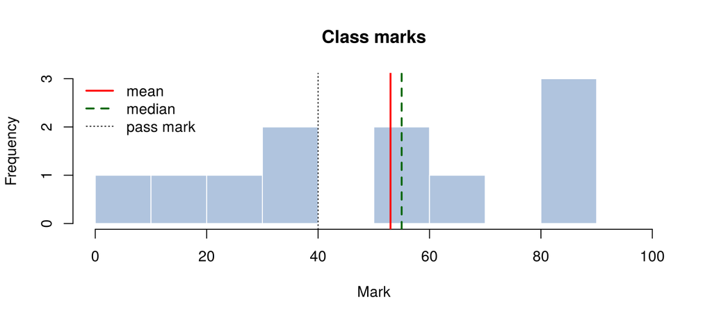

```r
hist(marks, breaks = seq(0, 100, by = 10),
     col = "lightsteelblue", border = "white",
     main = "Class marks", xlab = "Mark")
abline(v = mean(marks),   col = "red",       lwd = 2)
abline(v = median(marks), col = "darkgreen", lwd = 2, lty = 2)
abline(v = 40, lty = 3)
legend("topleft", c("mean", "median", "pass mark"), col = c("red", "darkgreen", "black"),
       lty = c(1, 2, 3), lwd = c(2, 2, 1), bty = "n")
```

**PREDICT** A typing error turns the 8th mark from 90 into 900. Which changes more: mean or median?

```r
marks_typo <- marks
marks_typo[8] <- 900
c(mean = mean(marks_typo), median = median(marks_typo))
```

```
##     mean   median
## 126.6364  55.0000
```

> The median is **robust** to extreme values; the mean is not.

# Part 2: Filtering (subsetting)

**PREDICT** What will `marks < 40` print: numbers, or something else?

```r
marks < 40          # a logical vector: one TRUE/FALSE per student
```

```
##  [1]  TRUE FALSE FALSE  TRUE  TRUE FALSE FALSE FALSE FALSE  TRUE FALSE
```

```r
marks[marks < 40]   # keep the TRUE ones: at-risk marks
```

```
## [1] 20 30 34 10
```

```r
sum(marks < 40)     # TRUE counts as 1
```

```
## [1] 4
```

```r
length(marks[marks < 40])
```

```
## [1] 4
```

```r
marks[marks >= 70]
```

```
## [1] 70 90 84 90
```

```r
sum(marks >= 70)
```

```
## [1] 4
```

```r
marks[marks > 50 & marks < 60]
```

```
## [1] 55
```

### Values versus positions

```r
marks[marks < 40]         # VALUES: what did they score?
```

```
## [1] 20 30 34 10
```

```r
which(marks < 40)         # POSITIONS: which students?
```

```
## [1]  1  4  5 10
```

```r
which.max(marks)          # PREDICT: there are two 90s. Which is returned?
```

```
## [1] 8
```

```r
which(marks == max(marks))
```

```
## [1]  8 11
```

```r
which.min(marks)
```

```
## [1] 10
```

### Debug my logic: I want marks strictly between 50 and 60

```r
marks[marks > 50 | marks < 60]   # wrong: every number is >50 OR <60
```

```
##  [1] 20 40 60 30 34 55 70 90 84 10 90
```

```r
marks[marks > 50 & marks < 60]   # right
```

```
## [1] 55
```

```r
marks[marks < 40 | marks > 85]   # a good use of OR: students needing a conversation
```

```
## [1] 20 30 34 90 10 90
```

### Recoding: change values that meet a condition

```r
capped <- marks
capped[capped > 85] <- 85       # cap marks at 85
capped
```

```
##  [1] 20 40 60 30 34 55 70 85 84 10 85
```

### `subset()` and missing values

```r
x <- c(1:10, NA)
x[x > 5]            # keeps the NA
```

```
## [1]  6  7  8  9 10 NA
```

```r
subset(x, x > 5)    # drops the NA
```

```
## [1]  6  7  8  9 10
```

**→ STUDENTS:** student page, Core and Challenge tasks (15 minutes). Use the filtering explorer to check predictions.

# Part 3: Data types, coercion and vectorisation

R has five atomic classes: **character, numeric (double), integer, logical, complex**.

```r
x <- 5;          class(x); typeof(x)
```

```
## [1] "numeric"
```

```
## [1] "double"
```

```r
y <- 5L;         class(y); typeof(y)     # L makes an integer
```

```
## [1] "integer"
```

```
## [1] "integer"
```

```r
z <- TRUE;       class(z)
```

```
## [1] "logical"
```

```r
w <- "Iftikhar"; class(w)
```

```
## [1] "character"
```

```r
v <- 2 + 3i;     class(v)
```

```
## [1] "complex"
```

### Special values

```r
1 / 0       # Inf
```

```
## [1] Inf
```

```r
1 / Inf     # 0
```

```
## [1] 0
```

```r
0 / 0       # NaN: not a number
```

```
## [1] NaN
```

### Mixing types: implicit coercion

**PREDICT** Each vector can only hold one type. What happens to each of these?

```r
c(1.7, "a")
```

```
## [1] "1.7" "a"
```

```r
c(TRUE, 2)
```

```
## [1] 1 2
```

```r
c("a", TRUE)
```

```
## [1] "a"    "TRUE"
```

```r
c(2L, 2.5)
```

```
## [1] 2.0 2.5
```

> R moves everything **up the ladder** to the most flexible type: logical → integer → double → character.

### Explicit coercion with `as.*()`

```r
x <- 0:6
as.numeric(x)
```

```
## [1] 0 1 2 3 4 5 6
```

```r
as.logical(x)        # 0 is FALSE, anything else TRUE
```

```
## [1] FALSE  TRUE  TRUE  TRUE  TRUE  TRUE  TRUE
```

```r
as.character(x)
```

```
## [1] "0" "1" "2" "3" "4" "5" "6"
```

```r
as.numeric(c("a", "b", "3"))   # nonsensical: NA with a warning
```

```
## [1] NA NA  3
```

### Vectorisation and recycling

```r
x <- c(3, 4, 2); y <- c(5, 3, 1)
x > y               # element by element
```

```
## [1] FALSE  TRUE  TRUE
```

```r
sqrt(c(9, 16, 25))
```

```
## [1] 3 4 5
```

```r
round(c(9.5, 16.3, 25.1))
```

```
## [1] 10 16 25
```

```r
x + 2                          # 2 is recycled: c(2, 2, 2)
```

```
## [1] 5 6 4
```

```r
c(1, 2, 4) + c(6, 0, 9, 20, 22, 11)   # shorter vector repeated
```

```
## [1]  7  2 13 21 24 15
```

```r
c(1, 2, 4) + c(6, 0, 9, 20, 22, 11, 12)   # warning: lengths are not multiples
```

```
## [1]  7  2 13 21 24 15 13
```

### `any()` and `all()`

```r
any(marks < 40)     # did anyone fail?
```

```
## [1] TRUE
```

```r
all(marks >= 10)    # did everyone get at least 10?
```

```
## [1] TRUE
```

### Rounding

```r
extra <- c(39.5543, 67.035, 69.5055)
marks2 <- c(marks, extra)       # combine vectors
round(marks2, 2)
```

```
##  [1] 20.00 40.00 60.00 30.00 34.00 55.00 70.00 90.00 84.00 10.00 90.00 39.55
## [13] 67.03 69.51
```

```r
round(marks2)
```

```
##  [1] 20 40 60 30 34 55 70 90 84 10 90 40 67 70
```

```r
floor(extra); ceiling(extra)
```

```
## [1] 39 67 69
```

```
## [1] 40 68 70
```

# Part 4: Generating data

```r
1:20
```

```
##  [1]  1  2  3  4  5  6  7  8  9 10 11 12 13 14 15 16 17 18 19 20
```

```r
seq(from = 12, to = 30, by = 3)
```

```
## [1] 12 15 18 21 24 27 30
```

```r
seq(0, 1, length.out = 5)
```

```
## [1] 0.00 0.25 0.50 0.75 1.00
```

```r
rep(8, 4)
```

```
## [1] 8 8 8 8
```

```r
rep(c(5, 6, 7), 4)
```

```
##  [1] 5 6 7 5 6 7 5 6 7 5 6 7
```

```r
rep(c(5, 6, 7), each = 2)
```

```
## [1] 5 5 6 6 7 7
```

### Random numbers and reproducibility

**PREDICT** Run `rnorm(5)` twice. Same numbers? Now with `set.seed(1)` before each.

```r
rnorm(5)
```

```
## [1]  0.3776344  0.6260293  0.1157325  0.3150513 -0.7945722
```

```r
rnorm(5)
```

```
## [1]  0.7681263  0.2522857 -0.6942794  0.8933466  1.3425013
```

```r
set.seed(1); rnorm(5)
```

```
## [1] -0.6264538  0.1836433 -0.8356286  1.5952808  0.3295078
```

```r
set.seed(1); rnorm(5)      # identical: reproducible
```

```
## [1] -0.6264538  0.1836433 -0.8356286  1.5952808  0.3295078
```

```r
set.seed(42)
sim_marks <- round(rnorm(200, mean = 55, sd = 15))
summary(sim_marks)
```

```
##    Min. 1st Qu.  Median    Mean 3rd Qu.    Max.
##   10.00   46.00   55.00   54.63   64.25   96.00
```

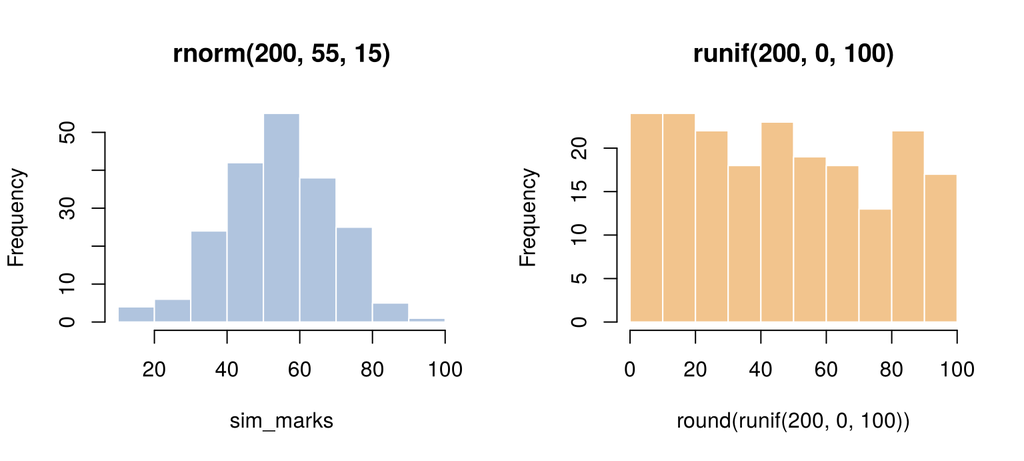

```r
par(mfrow = c(1, 2))
hist(sim_marks, col = "lightsteelblue", border = "white", main = "rnorm(200, 55, 15)")
hist(round(runif(200, 0, 100)), col = "#f2c48d", border = "white", main = "runif(200, 0, 100)")
```

```r
par(mfrow = c(1, 1))
```

**Ask:** Which histogram looks like real exam marks? Why can `rnorm()` give a mark below 0 or above 100?

### Sampling and bootstrapping

```r
set.seed(1)
sample(1:10, 4)                    # without replacement: no repeats
```

```
## [1] 9 4 7 1
```

```r
sample(1:10, 10, replace = TRUE)   # with replacement: repeats allowed (bootstrapping)
```

```
##  [1]  2  7  2  3  1  5  5 10  6 10
```

```r
set.seed(7)
population <- round(rnorm(10000, 60, 15))
sizes <- c(5, 10, 30, 100, 500, 2000)
sample_means <- sapply(sizes, function(n) mean(sample(population, n)))
round(sample_means, 2)
```

```
## [1] 57.20 55.90 62.53 61.46 60.95 59.77
```

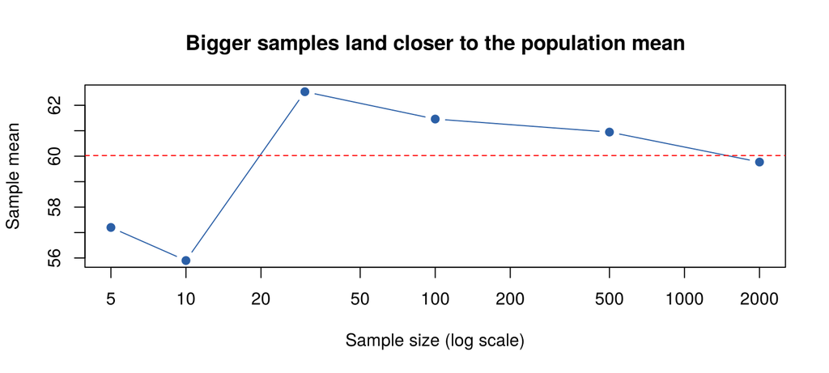

```r
plot(sizes, sample_means, log = "x", type = "b", pch = 19, col = "#2b5fa6",
     xlab = "Sample size (log scale)", ylab = "Sample mean",
     main = "Bigger samples land closer to the population mean")
abline(h = mean(population), lty = 2, col = "red")
```

# Part 5: Data structures

### Matrices (2-D, one type, filled column by column)

```r
m <- matrix(1:6, nrow = 2, ncol = 3)
m
```

```
##      [,1] [,2] [,3]
## [1,]    1    3    5
## [2,]    2    4    6
```

```r
matrix(1:6, nrow = 2, byrow = TRUE)
```

```
##      [,1] [,2] [,3]
## [1,]    1    2    3
## [2,]    4    5    6
```

```r
dim(m); nrow(m); ncol(m)
```

```
## [1] 2 3
```

```
## [1] 2
```

```
## [1] 3
```

```r
colnames(m) <- c("a", "b", "c")
m[2, 2]      # row 2, column 2
```

```
## b
## 4
```

```r
m[, "b"]     # all rows, column b
```

```
## [1] 3 4
```

```r
m[1, ]       # row 1, all columns
```

```
## a b c
## 1 3 5
```

```r
t(m)         # transpose
```

```
##   [,1] [,2]
## a    1    2
## b    3    4
## c    5    6
```

```r
cbind(x = 1:3, y = 10:12)
```

```
##      x  y
## [1,] 1 10
## [2,] 2 11
## [3,] 3 12
```

```r
rbind(x = 1:3, y = 10:12)
```

```
##   [,1] [,2] [,3]
## x    1    2    3
## y   10   11   12
```

### `apply()`: run a function over rows (1) or columns (2)

```r
scores <- matrix(c(55, 62, 71, 48, 80, 66,
                   58, 70, 65, 52, 85, 60), nrow = 6,
                 dimnames = list(paste0("S", 1:6), c("Test1", "Test2")))
scores
```

```
##    Test1 Test2
## S1    55    58
## S2    62    70
## S3    71    65
## S4    48    52
## S5    80    85
## S6    66    60
```

```r
apply(scores, 2, mean)    # column means: average per test
```

```
##    Test1    Test2
## 63.66667 65.00000
```

```r
apply(scores, 1, mean)    # row means: average per student
```

```
##   S1   S2   S3   S4   S5   S6
## 56.5 66.0 68.0 50.0 82.5 63.0
```

```r
colMeans(scores); rowSums(scores)
```

```
##    Test1    Test2
## 63.66667 65.00000
```

```
##  S1  S2  S3  S4  S5  S6
## 113 132 136 100 165 126
```

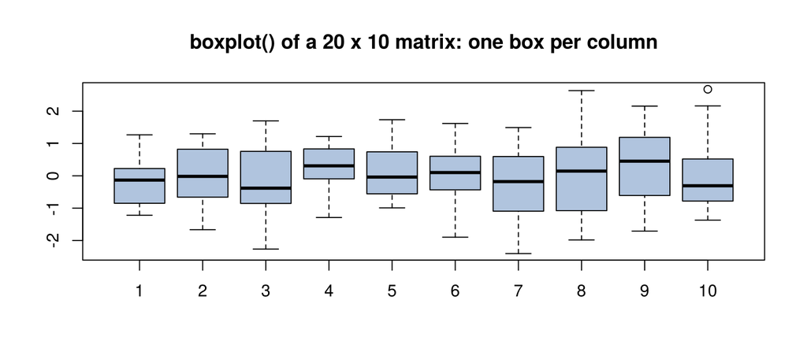

```r
set.seed(3)
boxplot(matrix(rnorm(200), 20, 10), col = "lightsteelblue",
        main = "boxplot() of a 20 x 10 matrix: one box per column")
```

### Lists: different types, different lengths

```r
student <- list(name = "Ali", age = 24, modules = c("COM747", "COM736"), passed = TRUE)
student$name
```

```
## [1] "Ali"
```

```r
student[["modules"]]
```

```
## [1] "COM747" "COM736"
```

```r
student[[3]][1]
```

```
## [1] "COM747"
```

```r
str(student)
```

```
## List of 4
##  $ name   : chr "Ali"
##  $ age    : num 24
##  $ modules: chr [1:2] "COM747" "COM736"
##  $ passed : logi TRUE
```

### Factors: categorical data

```r
answer <- factor(c("yes", "yes", "no", "yes", "no"))
answer
```

```
## [1] yes yes no  yes no
## Levels: no yes
```

```r
levels(answer)
```

```
## [1] "no"  "yes"
```

```r
table(answer)
```

```
## answer
##  no yes
##   2   3
```

```r
answer2 <- factor(c("yes", "yes", "no"), levels = c("no", "yes", "undecided"))
table(answer2)
```

```
## answer2
##        no       yes undecided
##         1         2         0
```

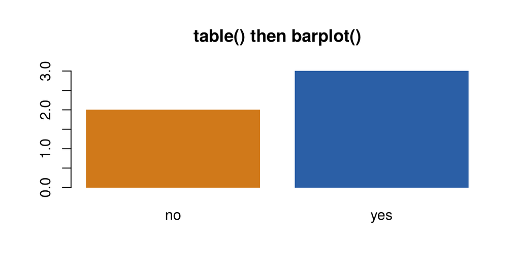

```r
barplot(table(answer), col = c("#d0791a", "#2b5fa6"), border = NA, main = "table() then barplot()")
```

### Missing values

```r
x <- c(1, 2, NA, 10, 3)
is.na(x)
```

```
## [1] FALSE FALSE  TRUE FALSE FALSE
```

```r
mean(x)                  # NA: R refuses to guess
```

```
## [1] NA
```

```r
mean(x, na.rm = TRUE)    # remove the NA first
```

```
## [1] 4
```

```r
y <- c(1, 2, NaN, NA, 4)
is.na(y); is.nan(y)      # NaN is also NA, but not the other way round
```

```
## [1] FALSE FALSE  TRUE  TRUE FALSE
```

```
## [1] FALSE FALSE  TRUE FALSE FALSE
```

```r
x_filled <- x
x_filled[is.na(x_filled)] <- mean(x, na.rm = TRUE)   # simple mean imputation
x_filled
```

```
## [1]  1  2  4 10  3
```

### Data frames: the structure you will use most

```r
students <- data.frame(
  name   = c("Ali", "Beth", "Chen", "Dara", "Eve"),
  campus = factor(c("London", "Birmingham", "London", "Manchester", "London")),
  mark   = c(50, 60, 38, 80, 70)
)
students
```

```
##   name     campus mark
## 1  Ali     London   50
## 2 Beth Birmingham   60
## 3 Chen     London   38
## 4 Dara Manchester   80
## 5  Eve     London   70
```

```r
str(students)
```

```
## 'data.frame':    5 obs. of  3 variables:
##  $ name  : chr  "Ali" "Beth" "Chen" "Dara" ...
##  $ campus: Factor w/ 3 levels "Birmingham","London",..: 2 1 2 3 2
##  $ mark  : num  50 60 38 80 70
```

```r
nrow(students); ncol(students); names(students)
```

```
## [1] 5
```

```
## [1] 3
```

```
## [1] "name"   "campus" "mark"
```

```r
students$mark
```

```
## [1] 50 60 38 80 70
```

```r
students[students$mark < 40, ]          # rows where mark < 40
```

```
##   name campus mark
## 3 Chen London   38
```

```r
students[, c("name", "mark")]
```

```
##   name mark
## 1  Ali   50
## 2 Beth   60
## 3 Chen   38
## 4 Dara   80
## 5  Eve   70
```

```r
students$grade <- ifelse(students$mark >= 70, "Distinction",
                  ifelse(students$mark >= 40, "Pass", "Fail"))
students
```

```
##   name     campus mark       grade
## 1  Ali     London   50        Pass
## 2 Beth Birmingham   60        Pass
## 3 Chen     London   38        Fail
## 4 Dara Manchester   80 Distinction
## 5  Eve     London   70 Distinction
```

```r
tapply(students$mark, students$campus, mean)   # mean mark per campus
```

```
## Birmingham     London Manchester
##   60.00000   52.66667   80.00000
```

# Part 6: Reading real data

```r
getwd()                       # where is R looking?
```

```
## [1] "/home/claude/com747/notebooks"
```

```r
# setwd("C:/path/to/your/week2/folder")   # change it if needed
rundata <- read.csv("rundata.csv", header = TRUE)
# rundata <- read.csv(file.choose())       # alternative: pick the file
head(rundata)
```

```
##   FirstRun SecondRun FinalRun
## 1     7.47     11.20    23.40
## 2    24.16     29.16    38.91
## 3    35.06     41.84    47.85
## 4    30.71     34.04    40.38
## 5    31.03     37.64    41.04
## 6    25.74     30.67    35.08
```

```r
tail(rundata, 3)
```

```
##    FirstRun SecondRun FinalRun
## 97    36.19     40.84    47.21
## 98    32.93     41.04    49.57
## 99    33.36     40.71    48.78
```

```r
dim(rundata)
```

```
## [1] 99  3
```

```r
str(rundata)
```

```
## 'data.frame':    99 obs. of  3 variables:
##  $ FirstRun : num  7.47 24.16 35.06 30.71 31.03 ...
##  $ SecondRun: num  11.2 29.2 41.8 34 37.6 ...
##  $ FinalRun : num  23.4 38.9 47.9 40.4 41 ...
```

```r
summary(rundata)
```

```
##     FirstRun       SecondRun        FinalRun
##  Min.   : 2.64   Min.   : 7.91   Min.   :17.21
##  1st Qu.:23.54   1st Qu.:27.77   1st Qu.:34.61
##  Median :29.24   Median :34.84   Median :41.58
##  Mean   :28.74   Mean   :33.96   Mean   :41.23
##  3rd Qu.:34.21   3rd Qu.:40.11   3rd Qu.:47.31
##  Max.   :56.14   Max.   :58.10   Max.   :66.67
```

> Each row is a runner; each number is the distance (km) on three consecutive runs.

```r
mean(rundata$FirstRun)
```

```
## [1] 28.7396
```

```r
sd(rundata$FirstRun)
```

```
## [1] 9.53072
```

```r
sum(rundata$FirstRun > 30)                          # how many ran more than 30 km?
```

```
## [1] 46
```

```r
rundata$Improvement <- rundata$SecondRun - rundata$FirstRun
sum(rundata$Improvement > 0)                        # how many improved?
```

```
## [1] 99
```

```r
apply(rundata[, 1:3], 2, mean)
```

```
##  FirstRun SecondRun  FinalRun
##  28.73960  33.95859  41.22939
```

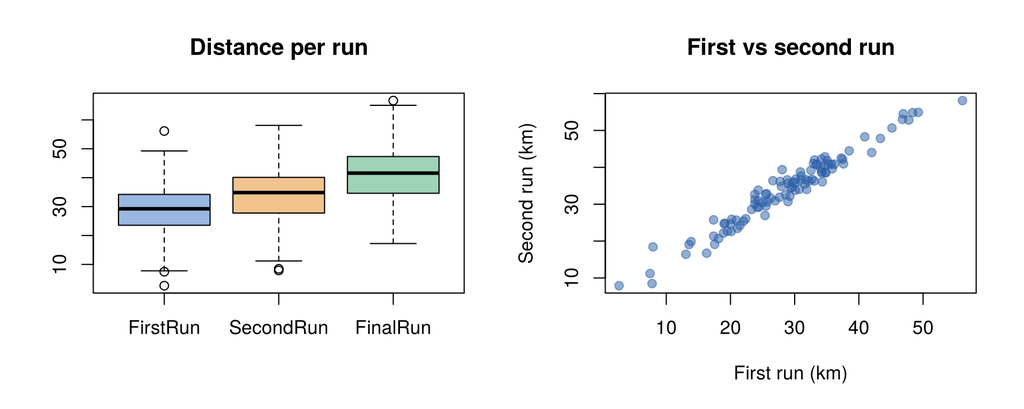

```r
par(mfrow = c(1, 2))
boxplot(rundata[, 1:3], col = c("#9ab7e0", "#f2c48d", "#9fd3b8"), main = "Distance per run")
plot(rundata$FirstRun, rundata$SecondRun, pch = 19, col = "#2b5fa680",
     xlab = "First run (km)", ylab = "Second run (km)", main = "First vs second run")
```

```r
par(mfrow = c(1, 1))
```

### Built-in datasets and packages

```r
# data()                 # list built-in datasets
mean(Nile); sd(Nile)     # annual flow of the River Nile
```

```
## [1] 919.35
```

```
## [1] 169.2275
```

```r
head(iris)
```

```
##   Sepal.Length Sepal.Width Petal.Length Petal.Width Species
## 1          5.1         3.5          1.4         0.2  setosa
## 2          4.9         3.0          1.4         0.2  setosa
## 3          4.7         3.2          1.3         0.2  setosa
## 4          4.6         3.1          1.5         0.2  setosa
## 5          5.0         3.6          1.4         0.2  setosa
## 6          5.4         3.9          1.7         0.4  setosa
```

```r
tapply(iris$Sepal.Length, iris$Species, mean)
```

```
##     setosa versicolor  virginica
##      5.006      5.936      6.588
```

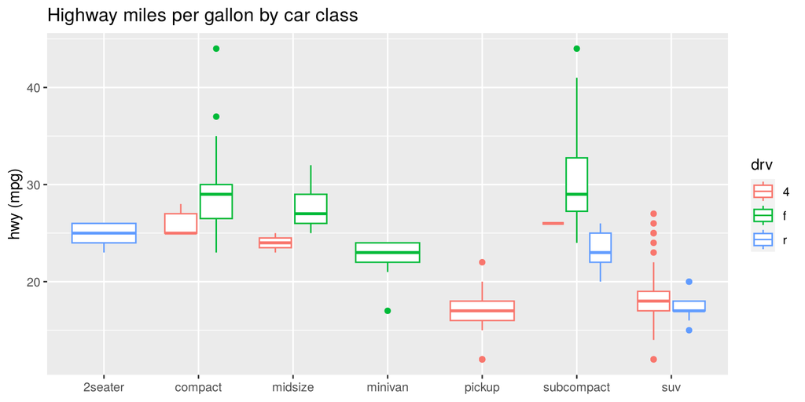

```r
# install.packages("ggplot2")   # once per computer
library(ggplot2)
ggplot(mpg, aes(class, hwy)) +
  geom_boxplot(aes(colour = drv)) +
  labs(title = "Highway miles per gallon by car class", x = NULL, y = "hwy (mpg)")
```

# Part 7: Control flow and your own functions (reference)

```r
x <- 5
if (x > 3) {
  y <- 10
} else {
  y <- 0
}
y
```

```
## [1] 10
```

```r
for (i in 1:3) print(marks[i])
```

```
## [1] 20
## [1] 40
## [1] 60
```

```r
i <- 1
while (i < 4) { print(i); i <- i + 1 }
```

```
## [1] 1
## [1] 2
## [1] 3
```

```r
grade <- function(mark, pass = 40) {
  if (mark >= 70) "Distinction" else if (mark >= pass) "Pass" else "Fail"
}
grade(72); grade(45); grade(30)
```

```
## [1] "Distinction"
```

```
## [1] "Pass"
```

```
## [1] "Fail"
```

```r
sapply(marks, grade)       # apply your function to every mark
```

```
##  [1] "Fail"        "Pass"        "Pass"        "Fail"        "Fail"
##  [6] "Pass"        "Distinction" "Distinction" "Distinction" "Fail"
## [11] "Distinction"
```

```r
f <- function(a, b) a * b
f(2, 3); f(b = 3, a = 2)   # named arguments can go in any order
```

```
## [1] 6
```

```
## [1] 6
```

```r
args(sd)
```

```
## function (x, na.rm = FALSE)
## NULL
```

# Assessment check (new data, 4 minutes)

```r
scores <- c(45, 72, 38, 61, 55, 81, 29, 67)
```

```r
scores <- c(45, 72, 38, 61, 55, 81, 29, 67)
mean(scores)               # 56
```

```
## [1] 56
```

```r
scores[scores < 40]        # 38 29
```

```
## [1] 38 29
```

```r
sum(scores >= 70)          # 2
```

```
## [1] 2
```

```r
which(scores < 40)         # 3 7
```

```
## [1] 3 7
```

# Summary

| Idea | R |
| --- | --- |
| Describe | `mean median sd var summary cumsum sort rev` |
| Filter | `x[x < 40]`, `sum(x < 40)`, `which()`, `subset()`, `&`, `\|` |
| Types | `class typeof as.numeric as.character`, coercion ladder |
| Generate | `seq rep rnorm runif sample set.seed` |
| Structures | `matrix apply list factor table data.frame` |
| Missing | `is.na`, `na.rm = TRUE` |
| Read data | `read.csv head str summary $` |

**Next week:** probability distributions: how likely is a value, and what shape is the data?